# NYC Flights Data

Aditya Kaul

November 4, 2015

```r
options(width = 100)

# Stardard libraries
#install.packages("nycflights13")
library(tidyr)
library(dplyr)
library(ggplot2)
library(nycflights13)
```

```r
#Load the flights data into a locally created data frame
flights_NYC <- flights

#Using the unite_() function to combine the first three columns of the dataframe
#to give us the year-month-day combined
flights_NYC <- unite_(flights_NYC,"flightdate",c("year","month","day"),sep = "-",remove = F)
#Check the structure of this new data frame
str(flights_NYC)
```

```
## Classes 'tbl_df', 'tbl' and 'data.frame':    336776 obs. of  17 variables:
##  $ flightdate: chr  "2013-1-1" "2013-1-1" "2013-1-1" "2013-1-1" ...
##  $ year      : int  2013 2013 2013 2013 2013 2013 2013 2013 2013 2013 ...
##  $ month     : int  1 1 1 1 1 1 1 1 1 1 ...
##  $ day       : int  1 1 1 1 1 1 1 1 1 1 ...
##  $ dep_time  : int  517 533 542 544 554 554 555 557 557 558 ...
##  $ dep_delay : num  2 4 2 -1 -6 -4 -5 -3 -3 -2 ...
##  $ arr_time  : int  830 850 923 1004 812 740 913 709 838 753 ...
##  $ arr_delay : num  11 20 33 -18 -25 12 19 -14 -8 8 ...
##  $ carrier   : chr  "UA" "UA" "AA" "B6" ...
##  $ tailnum   : chr  "N14228" "N24211" "N619AA" "N804JB" ...
##  $ flight    : int  1545 1714 1141 725 461 1696 507 5708 79 301 ...
##  $ origin    : chr  "EWR" "LGA" "JFK" "JFK" ...
##  $ dest      : chr  "IAH" "IAH" "MIA" "BQN" ...
##  $ air_time  : num  227 227 160 183 116 150 158 53 140 138 ...
##  $ distance  : num  1400 1416 1089 1576 762 ...
##  $ hour      : num  5 5 5 5 5 5 5 5 5 5 ...
##  $ minute    : num  17 33 42 44 54 54 55 57 57 58 ...
```

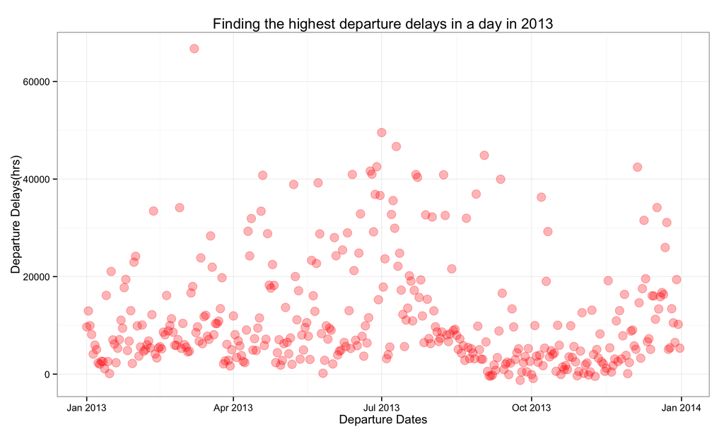

```r
#Convert the flightdate column to a date datatype
flights_NYC$flightdate <- as.Date(flights_NYC$flightdate)

#Create a data frame that aggregates the departure delay based on the date
flights_NYC_small <- flights_NYC %>%
  group_by(flightdate) %>%
  summarise(sum_delay = sum(dep_delay,na.rm=T))

#Create a time series plot showing date vs the departure delays
ggplot(flights_NYC_small,aes(flightdate,sum_delay))+
  geom_point(col=rgb(255,0,0,75,maxColorValue=255),pch=19,cex=4)+
  xlab("Departure Dates")+
  ylab("Departure Delays(hrs)")+
  ggtitle("Finding the highest departure delays in a day in 2013")+
  theme_bw()
```

```r
#Create a data frame that aggregates the departure delay based on the date, more
#specifically year, month and date
flights_NYC_small_two <- flights_NYC %>%
  group_by(year,month,day) %>%
  summarise(sum_delay = sum(dep_delay,na.rm=T))

#Create a subset from the above newly created data frame such that we consider
#only the dates for January 2013
flights_NYC_small_two_march <- subset(flights_NYC_small_two,month==3)
#Use the tail() function to check whether the last date is 31 Jan or not
tail(flights_NYC_small_two_march)
```

```
## Source: local data frame [6 x 4]
## Groups: year, month [1]
##
##    year month   day sum_delay
##   (int) (int) (int)     (dbl)
## 1  2013     3    26      2103
## 2  2013     3    27      2717
## 3  2013     3    28      6102
## 4  2013     3    29      2845
## 5  2013     3    30      1672
## 6  2013     3    31      5011
```

[figure not shown]

```r
#Create a time series plot similar to the one above
ggplot(flights_NYC_small_two_march,aes(day,sum_delay))+
  geom_point(col=rgb(255,0,0,75,maxColorValue=255),pch=19,cex=4)+
  xlab("Departure Dates(March)")+
  ylab("Departure Delays(hrs)")+
  ggtitle("Finding the highest departure delays in a day in January 2013")+
  theme_bw()
```

```r
#Creating a new column called monthnames to show which month we are considering
#in our analysis
flights_NYC$monthnames <- rep(NA,nrow(flights_NYC))
flights_NYC[flights_NYC$month==1,][,"monthnames"] <- "Jan"
flights_NYC[flights_NYC$month==2,][,"monthnames"] <- "Feb"
flights_NYC[flights_NYC$month==3,][,"monthnames"] <- "Mar"
flights_NYC[flights_NYC$month==4,][,"monthnames"] <- "Apr"
flights_NYC[flights_NYC$month==5,][,"monthnames"] <- "May"
flights_NYC[flights_NYC$month==6,][,"monthnames"] <- "Jun"
flights_NYC[flights_NYC$month==7,][,"monthnames"] <- "Jul"
flights_NYC[flights_NYC$month==8,][,"monthnames"] <- "Aug"
flights_NYC[flights_NYC$month==9,][,"monthnames"] <- "Sep"
flights_NYC[flights_NYC$month==10,][,"monthnames"] <- "Oct"
flights_NYC[flights_NYC$month==11,][,"monthnames"] <- "Nov"
flights_NYC[flights_NYC$month==12,][,"monthnames"] <- "Dec"

#Setting the monthnames as factors and also defining the levels of these monthnames
flights_NYC$monthnames <- factor(flights_NYC$monthnames,levels = c("Jan","Feb","Mar","Apr","May","Jun","Jul","Aug","Sep","Oct","Nov","Dec"))
#Checking the structure of the newly modified data frame
str(flights_NYC)
```

```
## Classes 'tbl_df', 'tbl' and 'data.frame':    336776 obs. of  18 variables:
##  $ flightdate: Date, format: "2013-01-01" "2013-01-01" "2013-01-01" ...
##  $ year      : int  2013 2013 2013 2013 2013 2013 2013 2013 2013 2013 ...
##  $ month     : int  1 1 1 1 1 1 1 1 1 1 ...
##  $ day       : int  1 1 1 1 1 1 1 1 1 1 ...
##  $ dep_time  : int  517 533 542 544 554 554 555 557 557 558 ...
##  $ dep_delay : num  2 4 2 -1 -6 -4 -5 -3 -3 -2 ...
##  $ arr_time  : int  830 850 923 1004 812 740 913 709 838 753 ...
##  $ arr_delay : num  11 20 33 -18 -25 12 19 -14 -8 8 ...
##  $ carrier   : chr  "UA" "UA" "AA" "B6" ...
##  $ tailnum   : chr  "N14228" "N24211" "N619AA" "N804JB" ...
##  $ flight    : int  1545 1714 1141 725 461 1696 507 5708 79 301 ...
##  $ origin    : chr  "EWR" "LGA" "JFK" "JFK" ...
##  $ dest      : chr  "IAH" "IAH" "MIA" "BQN" ...
##  $ air_time  : num  227 227 160 183 116 150 158 53 140 138 ...
##  $ distance  : num  1400 1416 1089 1576 762 ...
##  $ hour      : num  5 5 5 5 5 5 5 5 5 5 ...
##  $ minute    : num  17 33 42 44 54 54 55 57 57 58 ...
##  $ monthnames: Factor w/ 12 levels "Jan","Feb","Mar",..: 1 1 1 1 1 1 1 1 1 1 ...
```

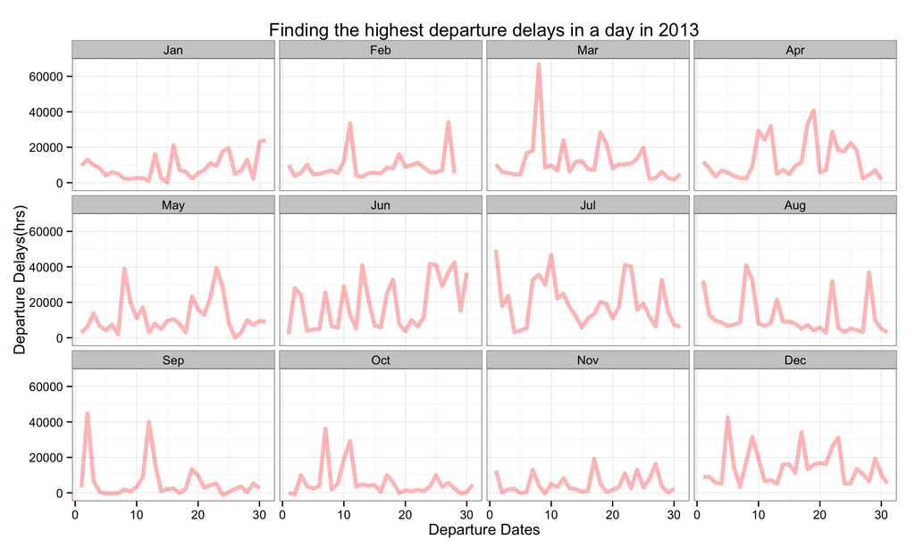

```r
#Creating a new column called monthnames to show which month we are considering
#in our analysis
flights_NYC_small_two$monthnames <- rep(NA,nrow(flights_NYC_small_two))
flights_NYC_small_two[flights_NYC_small_two$month==1,][,"monthnames"] <- "Jan"
flights_NYC_small_two[flights_NYC_small_two$month==2,][,"monthnames"] <- "Feb"
flights_NYC_small_two[flights_NYC_small_two$month==3,][,"monthnames"] <- "Mar"
flights_NYC_small_two[flights_NYC_small_two$month==4,][,"monthnames"] <- "Apr"
flights_NYC_small_two[flights_NYC_small_two$month==5,][,"monthnames"] <- "May"
flights_NYC_small_two[flights_NYC_small_two$month==6,][,"monthnames"] <- "Jun"
flights_NYC_small_two[flights_NYC_small_two$month==7,][,"monthnames"] <- "Jul"
flights_NYC_small_two[flights_NYC_small_two$month==8,][,"monthnames"] <- "Aug"
flights_NYC_small_two[flights_NYC_small_two$month==9,][,"monthnames"] <- "Sep"
flights_NYC_small_two[flights_NYC_small_two$month==10,][,"monthnames"] <- "Oct"
flights_NYC_small_two[flights_NYC_small_two$month==11,][,"monthnames"] <- "Nov"
flights_NYC_small_two[flights_NYC_small_two$month==12,][,"monthnames"] <- "Dec"

#Setting the monthnames as factors and also defining the levels of these monthnames
flights_NYC_small_two$monthnames <- factor(flights_NYC_small_two$monthnames,levels = c("Jan","Feb","Mar","Apr","May","Jun","Jul","Aug","Sep","Oct","Nov","Dec"))

#Creating a plot to visualize the departure delays on a daily basis per month
#which helps us in looking for a pattern
ggplot(flights_NYC_small_two,aes(day,sum_delay))+
  geom_line(col=rgb(255,0,0,75,maxColorValue=255),pch=19,cex=1.5)+
  xlab("Departure Dates")+
  ylab("Departure Delays(hrs)")+
  facet_wrap(~monthnames)+
  ggtitle("Finding the highest departure delays in a day in 2013")+
  theme_bw()
```

```r
#Here we have removed the NA values from the original dataset
flights_NYC_new <- na.omit(flights_NYC)

#Here we want to group by hours since we want to find delays over the entire
#duration of the day
hour_mean_depdelay <- flights_NYC_new %>%
  group_by(hour) %>%
  summarise(mean = mean(dep_delay,na.rm=T))

#We want to see what the max and min hour is in our calculation
max(flights_NYC_new$hour,na.rm = T)
```

```
## [1] 24
```

```r
min(flights_NYC_new$hour,na.rm = T)
```

```
## [1] 0
```

```
## geom_smooth: method="auto" and size of largest group is <1000, so using loess. Use 'method = x' to change the smoothing method.
```

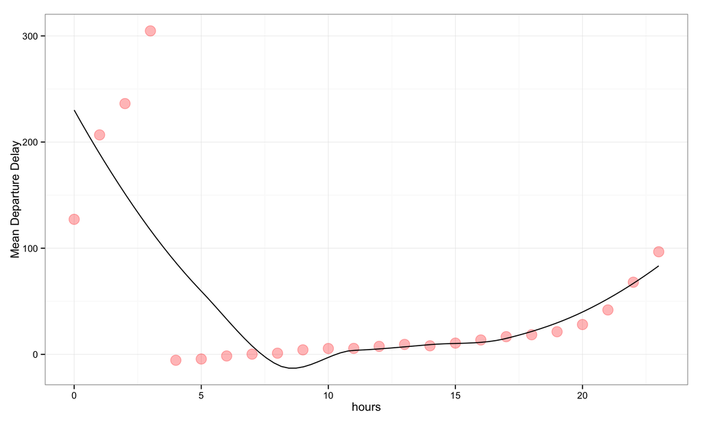

```r
#Since we have 24th hour as well as 0th hour which both mean the same thing
#we want to convert one to the other
#Here we convert all the 24 hour values to 0 hours
flights_NYC_new$hour[flights_NYC_new$hour==24] <- flights_NYC_new$hour[flights_NYC_new$hour==0]

#Here we want to group by hours since we want to find delays over the entire duration
#of the day
hour_mean_depdelay <- flights_NYC_new %>%
  group_by(hour) %>%
  summarise(mean = mean(dep_delay,na.rm=T))

#Create a plot that shows the departure delay over the course of a day
ggplot(hour_mean_depdelay,aes(hour,mean))+
  geom_point(col=rgb(255,0,0,75,maxColorValue=255),pch=19,cex=5)+
  geom_smooth(se=F,col="Black")+
  xlab("hours")+
  ylab("Mean Departure Delay")+
  theme_bw()
```

*As we can see from the plots below, weather seems to have some sort of impact on the departure delays of the flights from NYC. Although it is not possible for us to confirm whether it is these variables that are causing the delays, through the various plots below we have shown that there is a certain correlation between variables in the weather data set and the departure delay.*

*For temperature, we can see that there is a slight increase in the values of the departure delay for low temperatures and a relatively high delay at higher temperatures whereas at mild temperatures the delay is low.*

*Another variable that catches our attention is the presence of dew. As the amount of dew increases we can see that there is an increase in the departure delay which signifies some sort of correlation between the two variables. Similarly, we can see that with an increase in humidity the departure delay seems to increase as well.*

*For windspeed and windgust we have a strange relation. This is something that we can dig deeper into to find out the cause for such a relation. It seems as if at low wind speed and low wind gust the delay is higher.Note here that the speed and gust are in mph.*

*We also need to keep in mind that these are just correlations between the departure delay and the various weather variables. We are NOT saying that these variables solely are causing the delay. There could be several other confounding variables that have a bigger hand in the delay.*

*Our findings above could be the reason why delays are occuring or they could be the reason for some other variable which in turn is causing the delay.*

```r
#?weather
#Check to see what our flights from NYC data frame contains
head(flights_NYC)
```

```
## Source: local data frame [6 x 18]
##
##   flightdate  year month   day dep_time dep_delay arr_time arr_delay carrier tailnum flight origin
##       (date) (int) (int) (int)    (int)     (dbl)    (int)     (dbl)   (chr)   (chr)  (int)  (chr)
## 1 2013-01-01  2013     1     1      517         2      830        11      UA  N14228   1545    EWR
## 2 2013-01-01  2013     1     1      533         4      850        20      UA  N24211   1714    LGA
## 3 2013-01-01  2013     1     1      542         2      923        33      AA  N619AA   1141    JFK
## 4 2013-01-01  2013     1     1      544        -1     1004       -18      B6  N804JB    725    JFK
## 5 2013-01-01  2013     1     1      554        -6      812       -25      DL  N668DN    461    LGA
## 6 2013-01-01  2013     1     1      554        -4      740        12      UA  N39463   1696    EWR
## Variables not shown: dest (chr), air_time (dbl), distance (dbl), hour (dbl), minute (dbl),
##   monthnames (fctr)
```

```r
#Create a duplicate local copy of the data frame weather called weather_NYC
weather_NYC <- weather
#Check to see the what our weather_NYC data frame contains
head(weather_NYC)
```

```
## Source: local data frame [6 x 14]
## Groups: month, day, hour [6]
##
##   origin  year month   day  hour  temp  dewp humid wind_dir wind_speed wind_gust precip pressure
##    (chr) (dbl) (dbl) (int) (int) (dbl) (dbl) (dbl)    (dbl)      (dbl)     (dbl)  (dbl)    (dbl)
## 1    EWR  2013     1     1     0 37.04 21.92 53.97      230   10.35702  11.91865      0   1013.9
## 2    EWR  2013     1     1     1 37.04 21.92 53.97      230   13.80936  15.89154      0   1013.0
## 3    EWR  2013     1     1     2 37.94 21.92 52.09      230   12.65858  14.56724      0   1012.6
## 4    EWR  2013     1     1     3 37.94 23.00 54.51      230   13.80936  15.89154      0   1012.7
## 5    EWR  2013     1     1     4 37.94 24.08 57.04      240   14.96014  17.21583      0   1012.8
## 6    EWR  2013     1     1     6 39.02 26.06 59.37      270   10.35702  11.91865      0   1012.0
## Variables not shown: visib (dbl)
```

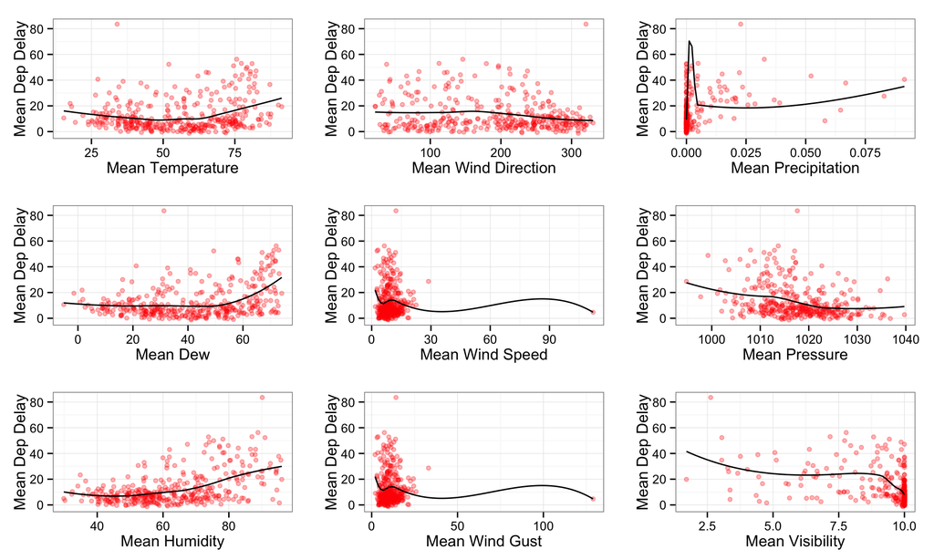

```r
#Check the structure of the data frame weather_NYC
#str(weather_NYC)

#Perform a left join on the flights_NYC and weather_NYC data frames
flights_weather_NYC <- left_join(flights_NYC,weather_NYC)

#Calculate the means of departure delays for each day for the entire year to give
#us 365 data points
dep_delay_mean<-flights_weather_NYC %>%
  group_by(month,day) %>%
  summarise(mean_delay = mean(dep_delay,na.rm=T))

#Calculate the means of temperature for each day for the entire year to give us
#365 data points
temp_mean <- flights_weather_NYC %>%
  group_by(month,day) %>%
  summarise(mean_temp = mean(temp,na.rm=T))

#Add means of temperature and means of departure delay to a single data frame by
#performing left join
mean_weather_delay <- left_join(dep_delay_mean,temp_mean)

#Calculate the means of dew for each day for the entire year to give us 365 data
#points
dew_mean <- flights_weather_NYC %>%
  group_by(month,day) %>%
  summarise(mean_dew = mean(dewp,na.rm=T))

#Add means of dew to our mean_weather_delay data frame
mean_weather_delay <- left_join(mean_weather_delay,dew_mean)

#Calculate the means of humidity for each day for the entire year to give us 365
#data points
humid_mean<-flights_weather_NYC %>%
  group_by(month,day) %>%
  summarise(mean_humid = mean(humid,na.rm=T))

#Add means of humidity to our mean_weather_delay data frame
mean_weather_delay <- left_join(mean_weather_delay,humid_mean)

#Calculate the means of wind direction(in degrees) for each day for the entire
#year to give us 365 data points
winddir_mean <- flights_weather_NYC %>%
  group_by(month,day) %>%
  summarise(mean_winddir = mean(wind_dir,na.rm=T))

#Add means of wind direction to our mean_weather_delay data frame
mean_weather_delay <- left_join(mean_weather_delay,winddir_mean)

#Calculate the means of wind speed(in mph) for each day for the entire year to
#give us 365 data points
windspeed_mean <- flights_weather_NYC %>%
  group_by(month,day) %>%
  summarise(mean_windspeed = mean(wind_speed,na.rm=T))

#Add means of wind speed to our mean_weather_delay data frame
mean_weather_delay <- left_join(mean_weather_delay,windspeed_mean)

#Calculate the means of wind gust(in mph) for each day for the entire year to
#give us 365 data points
windgust_mean <- flights_weather_NYC %>%
  group_by(month,day) %>%
  summarise(mean_windgust = mean(wind_gust,na.rm=T))

#Add means of wind gust to our mean_weather_delay data frame
mean_weather_delay <- left_join(mean_weather_delay,windgust_mean)

#Calculate the means of precipitation for each day for the entire year to give
#us 365 data points
precip_mean <- flights_weather_NYC %>%
  group_by(month,day) %>%
  summarise(mean_precip = mean(precip,na.rm=T))

#Add means of precipitation to our mean_weather_delay data frame
mean_weather_delay <- left_join(mean_weather_delay,precip_mean)

#Calculate the means of pressure for each day for the entire year to give us
#365 data points
pressure_mean <- flights_weather_NYC %>%
  group_by(month,day) %>%
  summarise(mean_pressure = mean(pressure,na.rm=T))

#Add means of pressure to our mean_weather_delay data frame
mean_weather_delay <- left_join(mean_weather_delay,pressure_mean)

#Calculate the means of visibility for each day for the entire year to give
#us 365 data points
visib_mean <- flights_weather_NYC %>%
  group_by(month,day) %>%
  summarise(mean_visib = mean(visib,na.rm=T))

#Add means of visibility to our mean_weather_delay data frame
mean_weather_delay <- left_join(mean_weather_delay,visib_mean)


p1 <- ggplot(mean_weather_delay,aes(mean_temp,mean_delay))+
  geom_point(col=rgb(255,0,0,75,maxColorValue=255),pch=19,cex=1.5)+
  xlab("Mean Temperature")+
  ylab("Mean Dep Delay")+
  geom_smooth(se=F,col="Black")+
  theme_bw()
p2 <- ggplot(mean_weather_delay,aes(mean_dew,mean_delay))+
  geom_point(col=rgb(255,0,0,75,maxColorValue=255),pch=19,cex=1.5)+
  xlab("Mean Dew")+
  ylab("Mean Dep Delay")+
  geom_smooth(se=F,col="Black")+
  theme_bw()
p3 <- ggplot(mean_weather_delay,aes(mean_humid,mean_delay))+
  geom_point(col=rgb(255,0,0,75,maxColorValue=255),pch=19,cex=1.5)+
  xlab("Mean Humidity")+
  ylab("Mean Dep Delay")+
  geom_smooth(se=F,col="Black")+
  theme_bw()
p4 <- ggplot(mean_weather_delay,aes(mean_winddir,mean_delay))+
  geom_point(col=rgb(255,0,0,75,maxColorValue=255),pch=19,cex=1.5)+
  xlab("Mean Wind Direction")+
  ylab("Mean Dep Delay")+
  geom_smooth(se=F,col="Black")+
  theme_bw()
p5 <- ggplot(mean_weather_delay,aes(mean_windspeed,mean_delay))+
  geom_point(col=rgb(255,0,0,75,maxColorValue=255),pch=19,cex=1.5)+
  xlab("Mean Wind Speed")+
  ylab("Mean Dep Delay")+
  geom_smooth(se=F,col="Black")+
  theme_bw()
p6 <- ggplot(mean_weather_delay,aes(mean_windgust,mean_delay))+
  geom_point(col=rgb(255,0,0,75,maxColorValue=255),pch=19,cex=1.5)+
  xlab("Mean Wind Gust")+
  ylab("Mean Dep Delay")+
  geom_smooth(se=F,col="Black")+
  theme_bw()
p7 <- ggplot(mean_weather_delay,aes(mean_precip,mean_delay))+
  geom_point(col=rgb(255,0,0,75,maxColorValue=255),pch=19,cex=1.5)+
  xlab("Mean Precipitation")+
  ylab("Mean Dep Delay")+
  geom_smooth(se=F,col="Black")+
  theme_bw()
p8 <- ggplot(mean_weather_delay,aes(mean_pressure,mean_delay))+
  geom_point(col=rgb(255,0,0,75,maxColorValue=255),pch=19,cex=1.5)+
  xlab("Mean Pressure")+
  ylab("Mean Dep Delay")+
  geom_smooth(se=F,col="Black")+
  theme_bw()
p9 <- ggplot(mean_weather_delay,aes(mean_visib,mean_delay))+
  geom_point(col=rgb(255,0,0,75,maxColorValue=255),pch=19,cex=1.5)+
  xlab("Mean Visibility")+
  ylab("Mean Dep Delay")+
  geom_smooth(se=F,col="Black")+
  theme_bw()


#Using the multiple plot function from cookbook-r.com
# Multiple plot function
#
# ggplot objects can be passed in ..., or to plotlist (as a list of ggplot objects)
# - cols:   Number of columns in layout
# - layout: A matrix specifying the layout. If present, 'cols' is ignored.
#
# If the layout is something like matrix(c(1,2,3,3), nrow=2, byrow=TRUE),
# then plot 1 will go in the upper left, 2 will go in the upper right, and
# 3 will go all the way across the bottom.
#
multiplot <- function(..., plotlist=NULL, file, cols=1, layout=NULL) {
  library(grid)

  # Make a list from the ... arguments and plotlist
  plots <- c(list(...), plotlist)

  numPlots = length(plots)

  # If layout is NULL, then use 'cols' to determine layout
  if (is.null(layout)) {
    # Make the panel
    # ncol: Number of columns of plots
    # nrow: Number of rows needed, calculated from # of cols
    layout <- matrix(seq(1, cols * ceiling(numPlots/cols)),
                    ncol = cols, nrow = ceiling(numPlots/cols))
  }

 if (numPlots==1) {
    print(plots[[1]])

  } else {
    # Set up the page
    grid.newpage()
    pushViewport(viewport(layout = grid.layout(nrow(layout), ncol(layout))))

    # Make each plot, in the correct location
    for (i in 1:numPlots) {
      # Get the i,j matrix positions of the regions that contain this subplot
      matchidx <- as.data.frame(which(layout == i, arr.ind = TRUE))

      print(plots[[i]], vp = viewport(layout.pos.row = matchidx$row,
                                      layout.pos.col = matchidx$col))
    }
  }
}

#Create all the ggplots on a single page
multiplot(p1,p2,p3,p4,p5,p6,p7,p8,p9,cols=3)
```

*As the number of seats increases on a flight we assume that the size of the flight increases. Our second analysis was to see if there was a delay in departure for heavier and bigger sized flights(more seats) than the smaller flights(lesser seats). To make the analysis clearer we segregated the plots on basis of manufacturers.*

```r
#Check to see the first six rows of the flights_NYC data frame
head(flights_NYC)
```

```
## Source: local data frame [6 x 18]
##
##   flightdate  year month   day dep_time dep_delay arr_time arr_delay carrier tailnum flight origin
##       (date) (int) (int) (int)    (int)     (dbl)    (int)     (dbl)   (chr)   (chr)  (int)  (chr)
## 1 2013-01-01  2013     1     1      517         2      830        11      UA  N14228   1545    EWR
## 2 2013-01-01  2013     1     1      533         4      850        20      UA  N24211   1714    LGA
## 3 2013-01-01  2013     1     1      542         2      923        33      AA  N619AA   1141    JFK
## 4 2013-01-01  2013     1     1      544        -1     1004       -18      B6  N804JB    725    JFK
## 5 2013-01-01  2013     1     1      554        -6      812       -25      DL  N668DN    461    LGA
## 6 2013-01-01  2013     1     1      554        -4      740        12      UA  N39463   1696    EWR
## Variables not shown: dest (chr), air_time (dbl), distance (dbl), hour (dbl), minute (dbl),
##   monthnames (fctr)
```

```r
#Create a local data frame called planes_data which is a replica of the
#planes data frame
planes_data<-planes
#Check to see the first six rows of the planes_data data frame
head(planes_data)
```

```
## Source: local data frame [6 x 9]
##
##   tailnum  year                    type     manufacturer     model engines seats speed    engine
##     (chr) (int)                   (chr)            (chr)     (chr)   (int) (int) (int)     (chr)
## 1  N10156  2004 Fixed wing multi engine          EMBRAER EMB-145XR       2    55    NA Turbo-fan
## 2  N102UW  1998 Fixed wing multi engine AIRBUS INDUSTRIE  A320-214       2   182    NA Turbo-fan
## 3  N103US  1999 Fixed wing multi engine AIRBUS INDUSTRIE  A320-214       2   182    NA Turbo-fan
## 4  N104UW  1999 Fixed wing multi engine AIRBUS INDUSTRIE  A320-214       2   182    NA Turbo-fan
## 5  N10575  2002 Fixed wing multi engine          EMBRAER EMB-145LR       2    55    NA Turbo-fan
## 6  N105UW  1999 Fixed wing multi engine AIRBUS INDUSTRIE  A320-214       2   182    NA Turbo-fan
```

```r
#Perform a left join between the data frames flights_NYC and planes_data
#on their "tailnum"
flights_planes_data <- left_join(flights_NYC,planes_data,by="tailnum")

#Calculate the age of the planes by subtracting the year that it flew,
#that is, 2013(year.x)
#and the year that it was manufactured in, that is, year.y
flights_planes_data$age <- flights_planes_data$year.x-flights_planes_data$year.y

#Create a plot to show the relation between the departure delay and the
#age of the flight
#ggplot(flights_planes_data,aes(age,dep_delay))+
#  geom_point(col=rgb(255,0,0,75,maxColorValue=255),pch=19,cex=1.5)+
#  xlab("Flight Age")+
#  ylab("Departure Delay")+
#  geom_smooth(se=F,col="Black")+
#  theme_bw()

#Calculate the number of unique values that we have of engine
length(unique(flights_planes_data$age))
```

```
## [1] 47
```

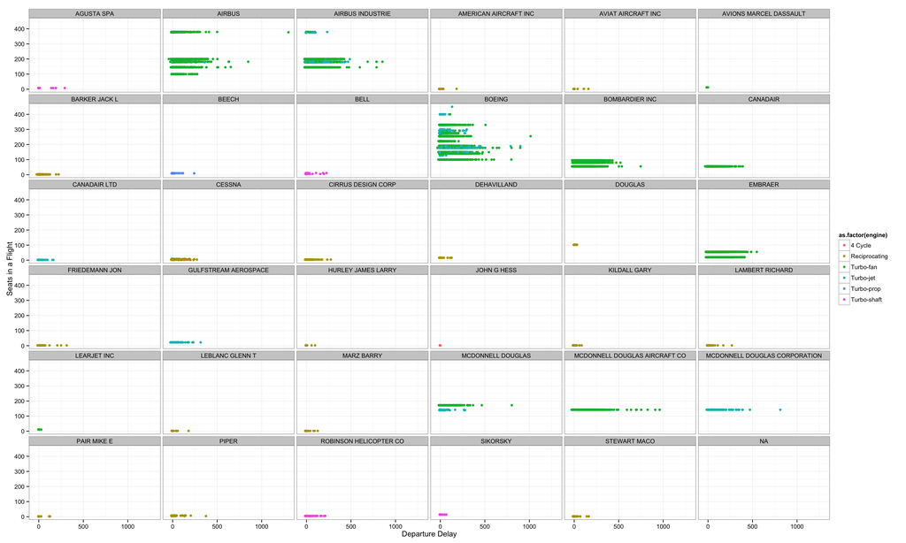

```r
#Create a plot to show seats vs departure delay and the engine is used as
#a factor to differentiate via color
ggplot(flights_planes_data,aes(dep_delay,seats,col=as.factor(engine)))+
  geom_point(pch=19,cex=1.5)+
  xlab("Departure Delay")+
  ylab("Seats in a Flight")+
  facet_wrap(~manufacturer)+
  theme_bw()
```